# ICE Annina 10x sequencing analysis - QC/processing/integration of organoid data

An object of class Seurat 17752 features across 17065 samples within 1 assay Active assay: RNA (17752 features, 0 variable features) 1 layer present: counts

```
############# QC b/ filtering #############
```

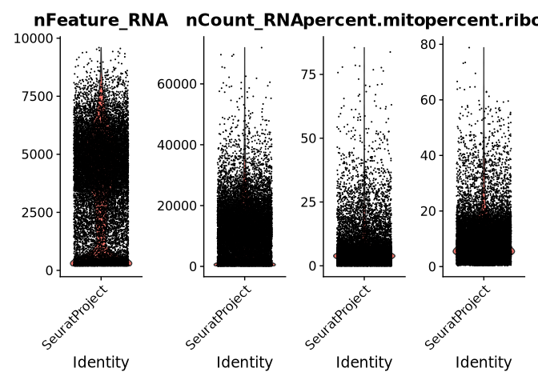

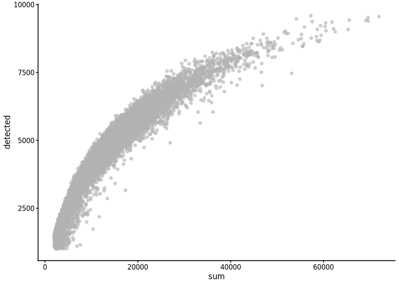

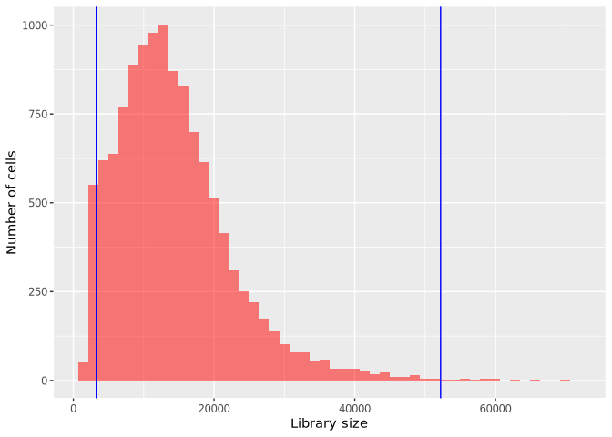

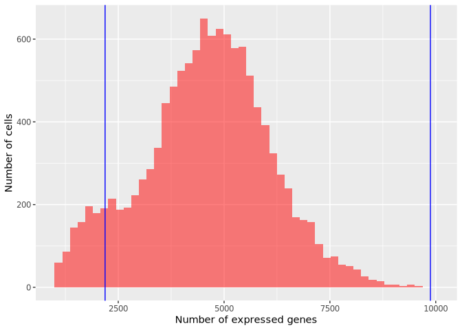

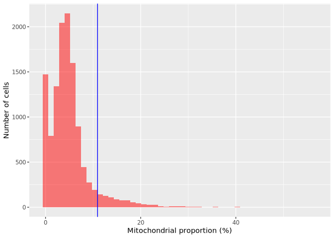

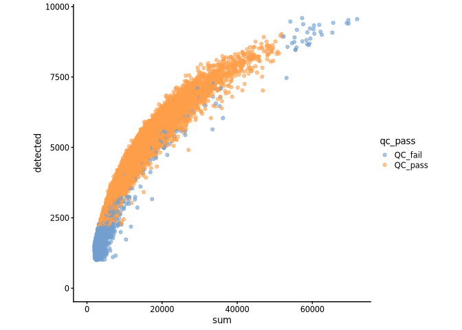

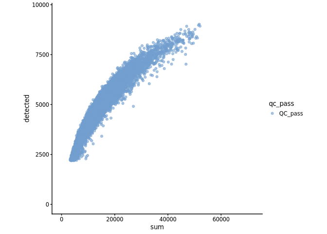

```
############# QC a/ filtering #############
```

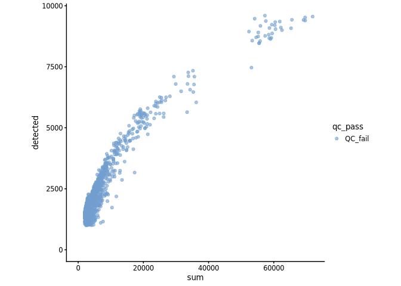

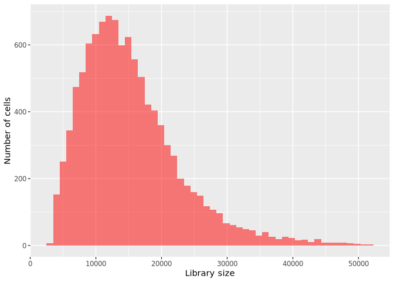

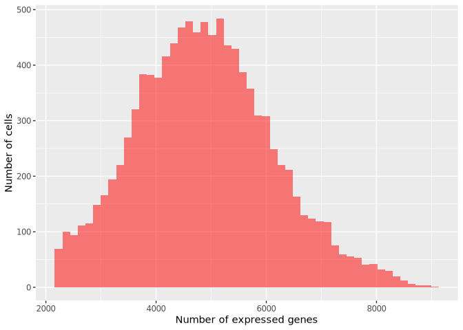

```
############# Additional QC metrics #############
```

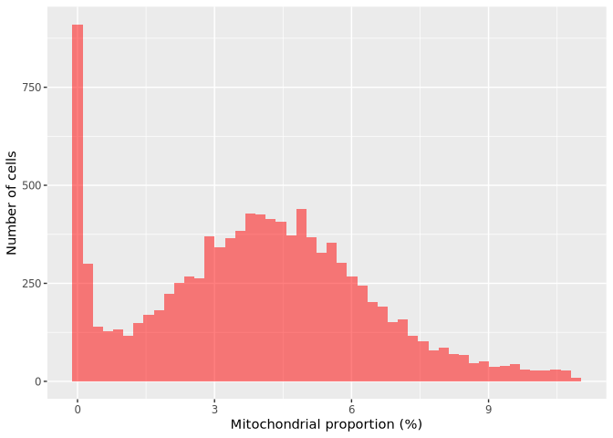

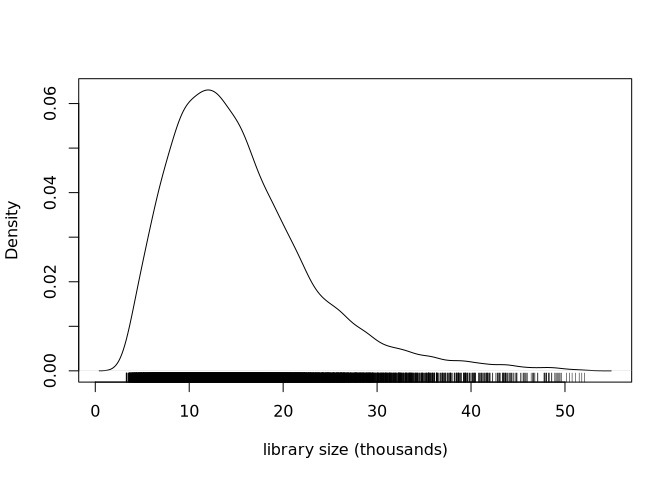

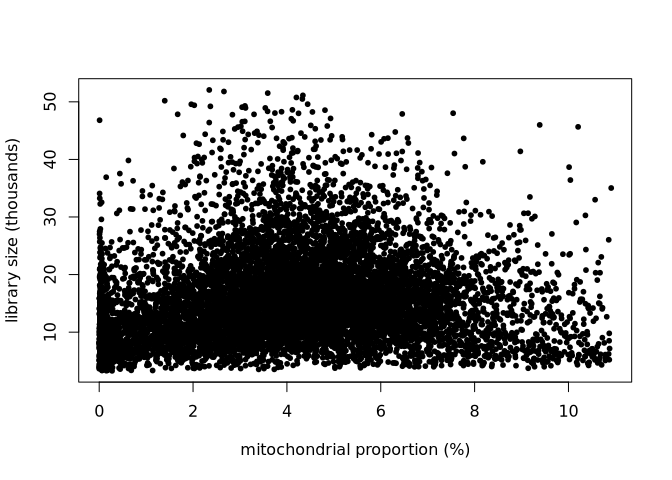

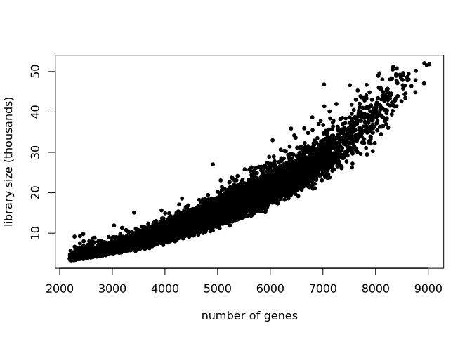

An object of class Seurat 17752 features across 10621 samples within 1 assay Active assay: RNA (17752 features, 0 variable features) 2 layers present: counts, data

**COp1_cell_4mo_4dpi_wt2**

An object of class Seurat 17616 features across 15105 samples within 1 assay Active assay: RNA (17616 features, 0 variable features) 1 layer present: counts

```
############# QC b/ filtering #############
```

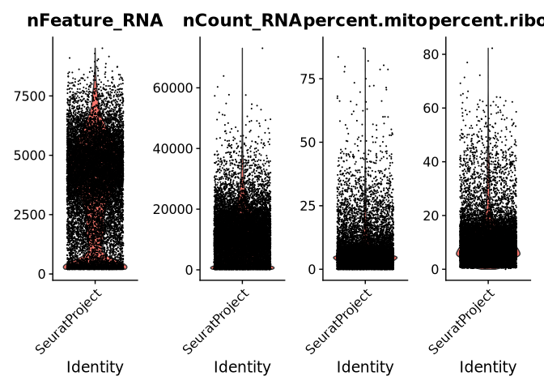

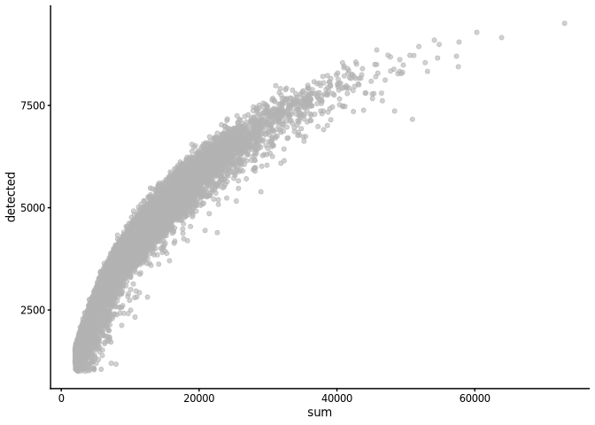

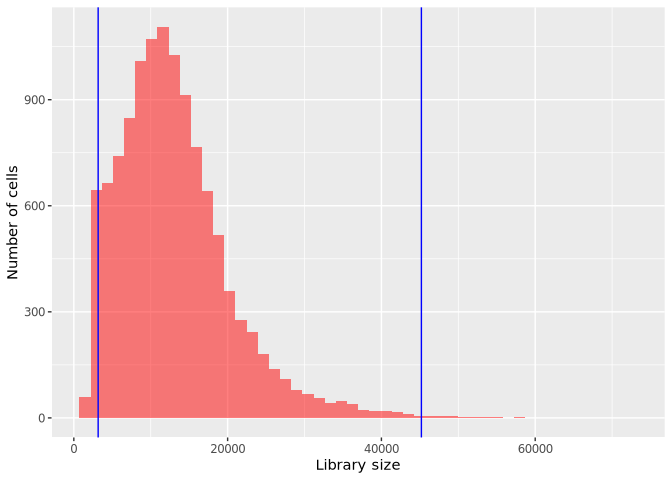

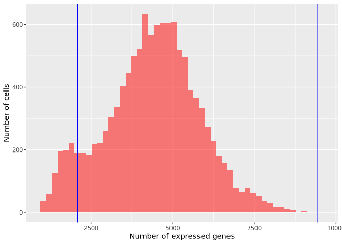

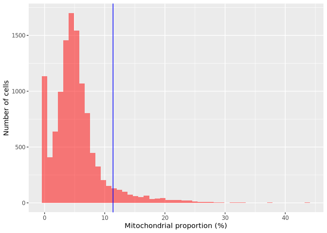

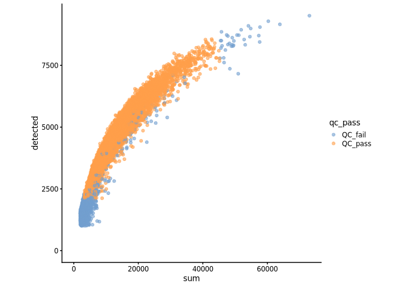

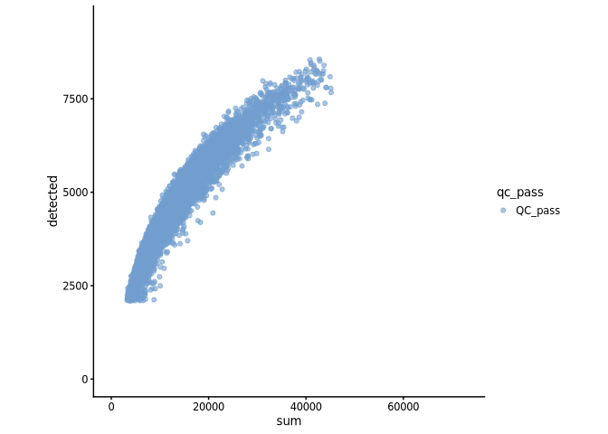

```
############# QC a/ filtering #############
```

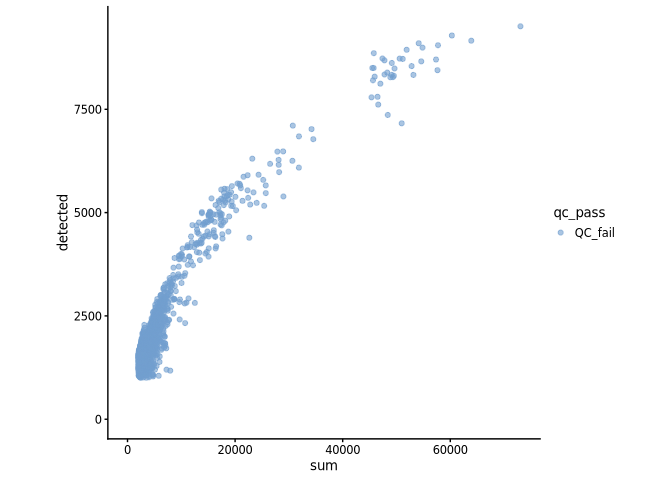

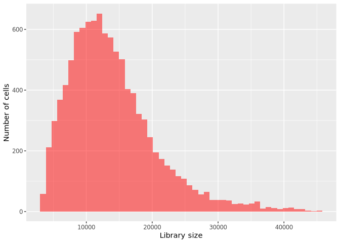

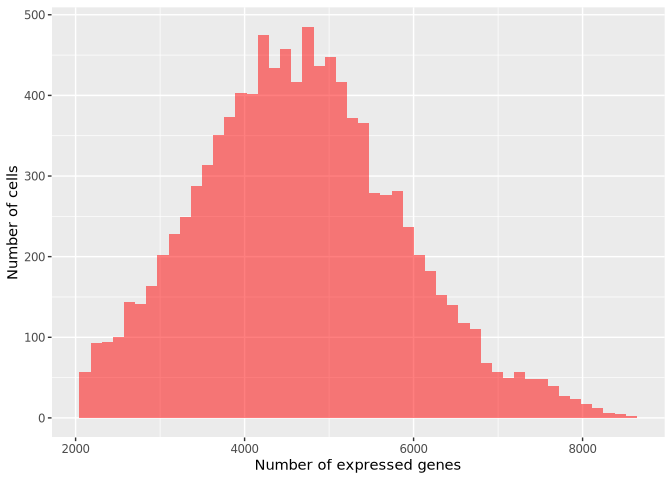

```
############# Additional QC metrics #############
```

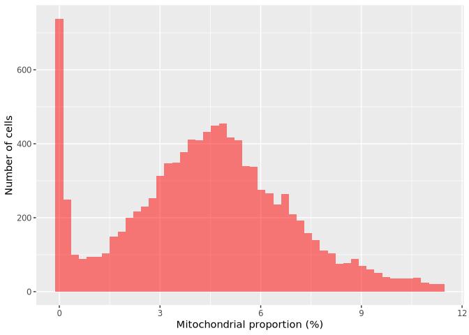

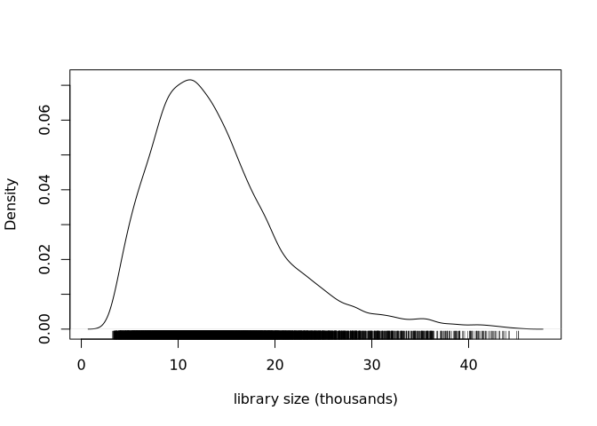

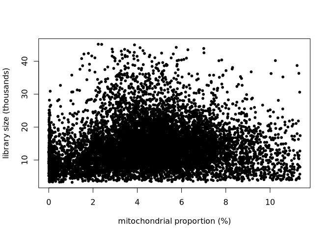

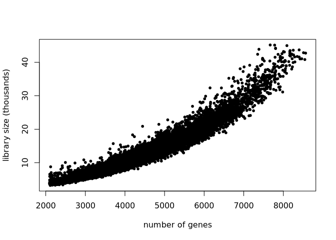

An object of class Seurat 17616 features across 10348 samples within 1 assay Active assay: RNA (17616 features, 0 variable features) 2 layers present: counts, data

**COp1_cell_4mo_4wpi_mCh**